# A whistlestop overview of Linear Models, Generalised Linear Models and GLMMs

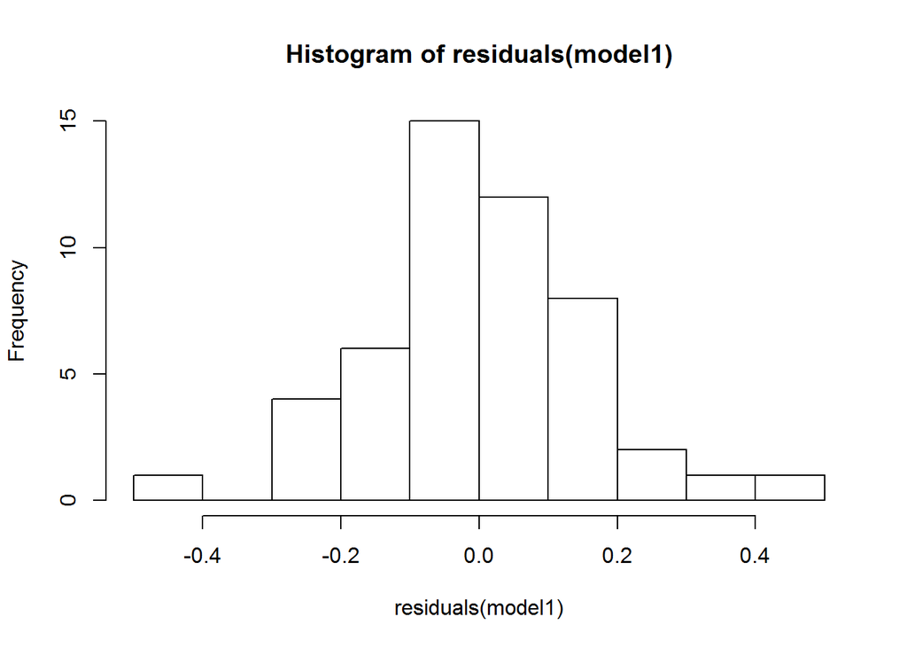

```r
# Model validation

# Are residuals normally distributed?

## To visualize
hist(residuals(model1))
```

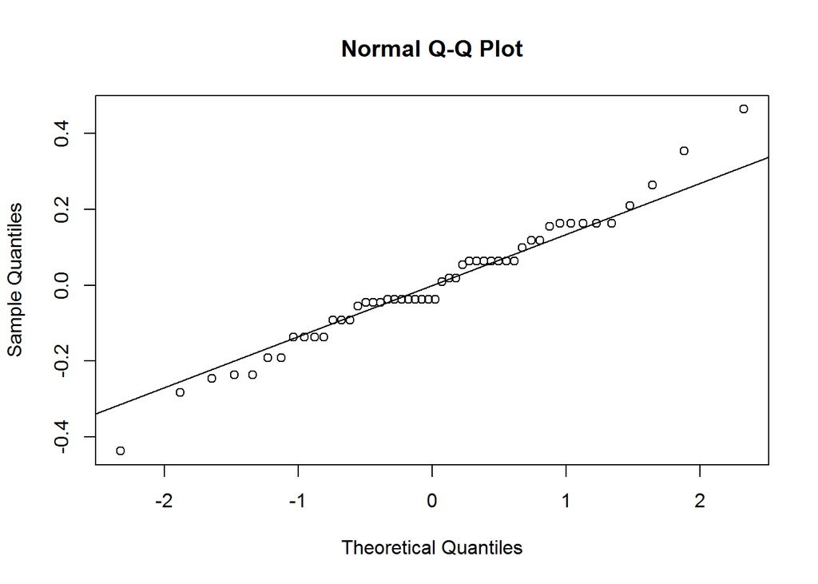

```r
qqnorm(residuals(model1))
qqline(residuals(model1))
```

```r
### to formally test this examine you may use shapiro.test (there are many options), ## P > 0.05 indicates distribution is not significantly different from normal.

shapiro.test(residuals(model1))
```

```
##
##  Shapiro-Wilk normality test
##
## data:  residuals(model1)
## W = 0.97916, p-value = 0.517
```

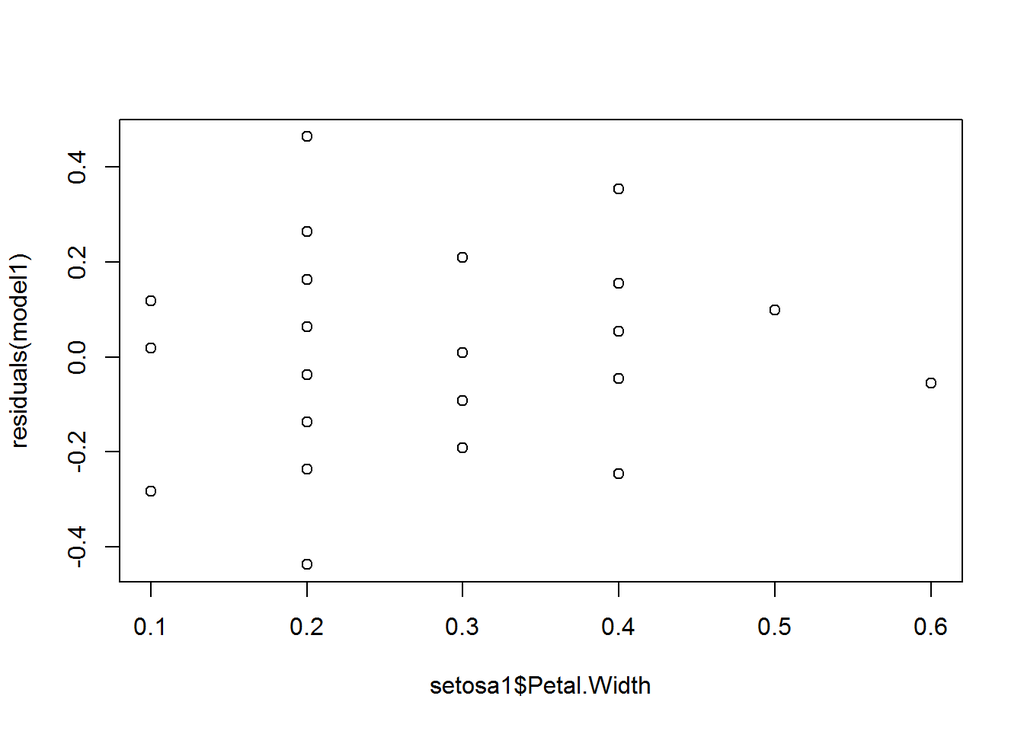

```r
#   Shapiro-Wilk normality test
#
# data:  residuals(model1)
# W = 0.97916, p-value = 0.517

####


# Homegeneity of variance

## plot residuals against predictor variables. Here you should see no pattern

plot(residuals(model1) ~ setosa1$Petal.Width)
```

```r
## The model can be easily expanded to add more variables using "+" or "*" for interactions

#e.g.


model2 <- lm(Petal.Length ~ Petal.Width + Species, data = iris) ## etc

######
```

## **Generalised** linear models

### The key difference between *General* Linear Models and **Generalised** Linear Models is that in Generalised Linear Models are designed for use with non-normal response data.

For these models you must specify an alternative distribution which represents your data (these are known as families):

- Gamma - For non-normal continous data, bounded at zero
- Binomial - for presence/absence data or proportions
- Poisson - Count data
- Negative Binomial - Overdispersed countdata
- Zero-Inflated Poisson/Negative Binomial for data with a lot of zeros.

Writing these models in R is like writing a linear model except that you use the function ‘glm’ and must now specify the distribution ‘family’ and oftern the link function for that family, for all those listed above ‘log’ is the most commonly used link function except the Binomial for which a ‘logit’ link is most commonly used.

e.g.

i.e. glm(dependent variable~Explanatory variable, family = distribution(link = “”), data = dataset)

Note: As previously, normality should be judged based on the distribution of the model residuals (not the raw data).

*Further examples of GLM’s and data from different distribution families is given in the code file “more_GLM_examples_kellyr_25_10_2017”

```r
###


chem <- read.csv("chem_example.csv")

##### This dataset contains data on soil chemistry for quadrats within 6 sites.
##### The variable of interest is burning, in particular it's effect on soil chemistry


names(chem)
```

```
##  [1] "Site"    "Burnt"   "Habitat" "pH"      "P"       "K"       "Mg"
##  [8] "S"       "Ca"      "Total.N" "Total.C"
```

```r
str(chem)
```

```
## 'data.frame':    122 obs. of  11 variables:
##  $ Site   : Factor w/ 6 levels "CH","EM","GR",..: 1 1 1 1 1 1 1 1 1 1 ...
##  $ Burnt  : Factor w/ 2 levels "N","Y": 1 1 1 1 1 1 1 1 2 2 ...
##  $ Habitat: Factor w/ 3 levels "Bog","DH","WH": 1 1 1 1 1 1 1 3 1 1 ...
##  $ pH     : num  4.12 4.08 4.21 4.12 3.94 4.04 4.18 4.2 4.24 4.11 ...
##  $ P      : num  4.6 3.8 3.1 3 11.9 4 3.2 5.4 4.1 2.5 ...
##  $ K      : int  53 76 68 79 89 64 44 40 81 67 ...
##  $ Mg     : int  222 164 168 278 303 276 169 122 139 194 ...
##  $ S      : num  9.59 9.57 11.2 8.74 7.49 8.3 7.06 6.71 7.6 7.65 ...
##  $ Ca     : int  249 173 177 256 314 222 191 200 217 207 ...
##  $ Total.N: num  1.78 2 2.28 2.22 2.43 1.74 1.74 1.62 1.54 1.47 ...
##  $ Total.C: num  52.5 51.6 51.2 52.7 53.2 52.8 51.7 50.8 52.7 52 ...
```

```r
summary(chem)
```

```
##  Site    Burnt  Habitat        pH              P                K
##  CH:18   N:56   Bog:80   Min.   :3.900   Min.   : 0.700   Min.   : 28.00
##  EM:34   Y:66   DH :22   1st Qu.:4.030   1st Qu.: 3.125   1st Qu.: 63.25
##  GR:11          WH :20   Median :4.130   Median : 4.200   Median : 80.00
##  MN:20                   Mean   :4.182   Mean   : 4.684   Mean   : 84.55
##  SA:19                   3rd Qu.:4.250   3rd Qu.: 5.650   3rd Qu.:101.75
##  SH:20                   Max.   :5.760   Max.   :13.400   Max.   :198.00
##
##        Mg              S                Ca           Total.N
##  Min.   : 19.0   Min.   : 4.860   Min.   :  0.0   Min.   :0.120
##  1st Qu.:129.8   1st Qu.: 8.070   1st Qu.:118.0   1st Qu.:1.552
##  Median :182.0   Median : 9.600   Median :165.0   Median :1.805
##  Mean   :179.2   Mean   : 9.724   Mean   :173.6   Mean   :1.751
##  3rd Qu.:219.5   3rd Qu.:11.100   3rd Qu.:218.0   3rd Qu.:2.087
##  Max.   :309.0   Max.   :17.100   Max.   :568.0   Max.   :2.690
##                                   NA's   :1
##     Total.C
##  Min.   : 2.50
##  1st Qu.:45.65
##  Median :51.55
##  Mean   :45.91
##  3rd Qu.:52.60
##  Max.   :55.90
##
```

```r
#### Let's look at P - Phosphorus

summary(chem$P)
```

```
##    Min. 1st Qu.  Median    Mean 3rd Qu.    Max.
##   0.700   3.125   4.200   4.684   5.650  13.400
```

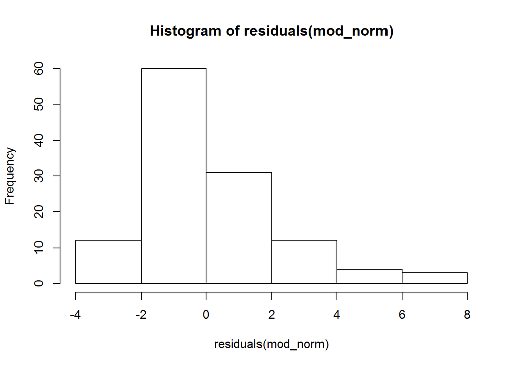

```r
###
#### an optimist fits a normal model first..

mod_norm <- lm(P~Burnt*Habitat, data = chem)

hist(residuals(mod_norm))
```

```r
shapiro.test(residuals(mod_norm))
```

```
##
##  Shapiro-Wilk normality test
##
## data:  residuals(mod_norm)
## W = 0.90912, p-value = 4.944e-07
```

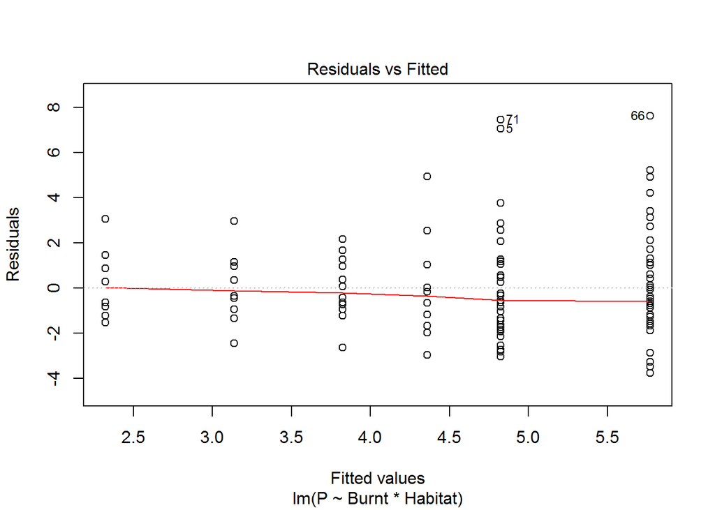

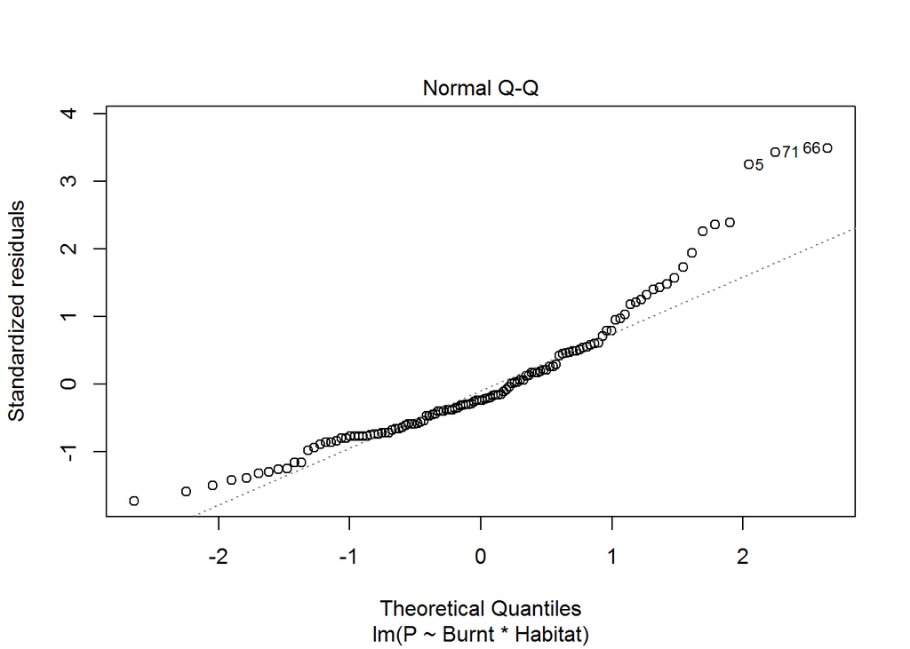

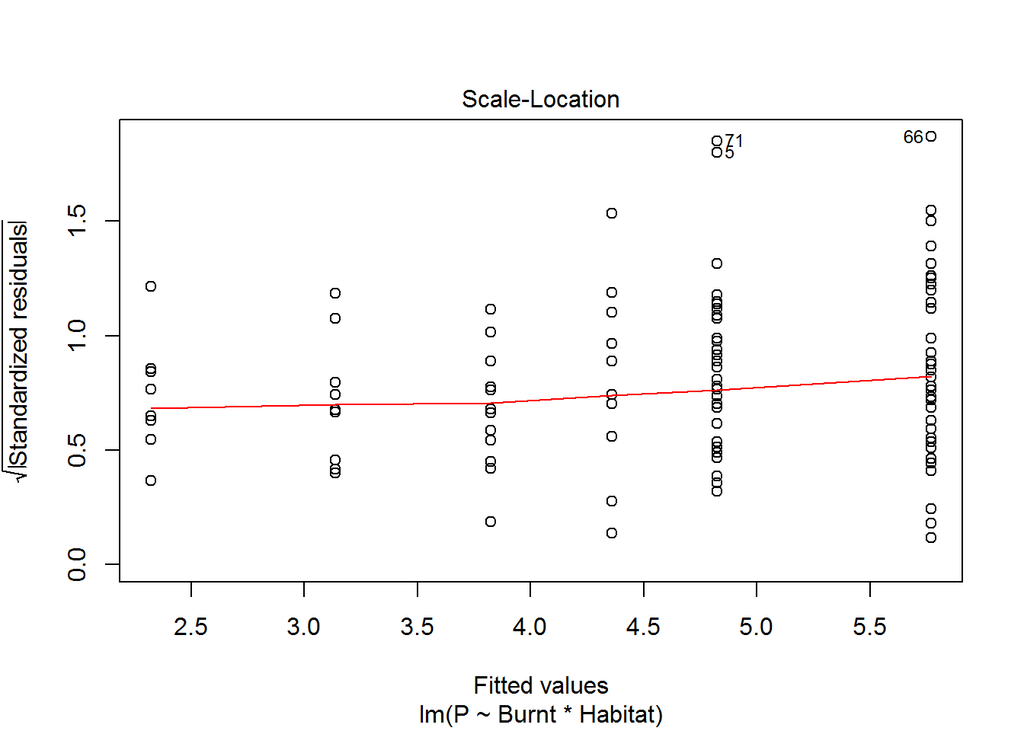

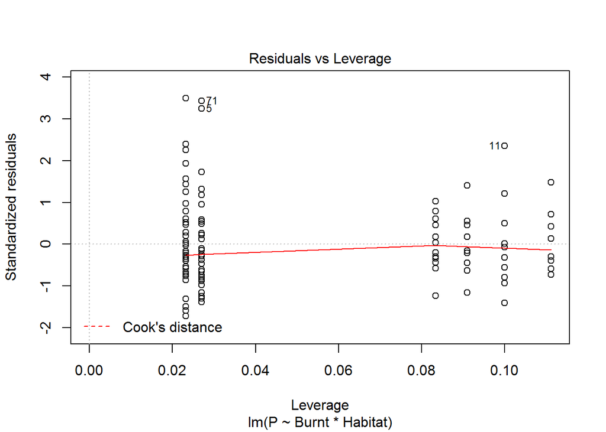

```r
##### not normal...

plot(mod_norm)
```

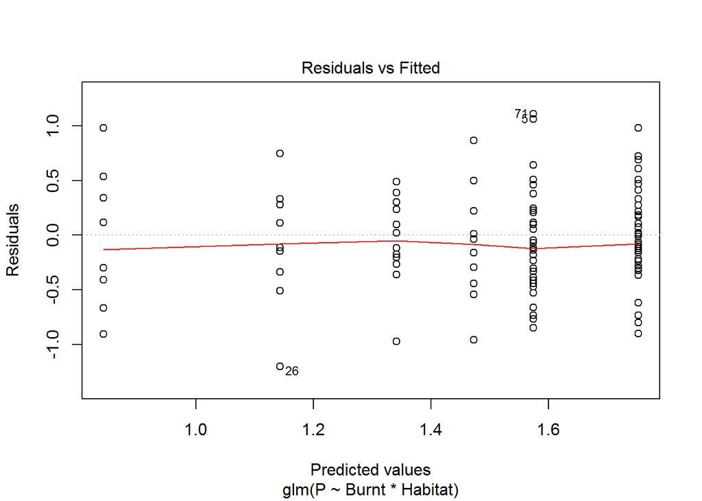

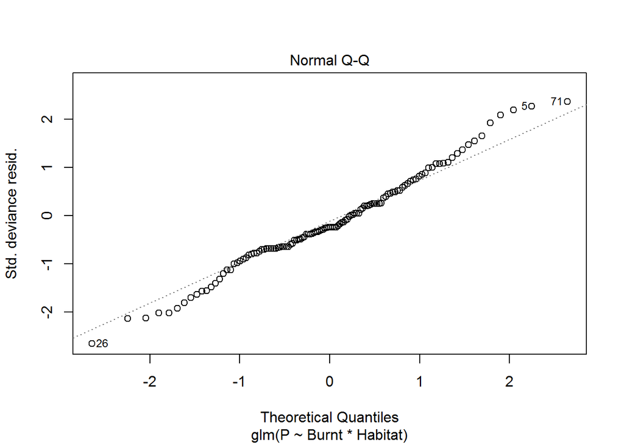

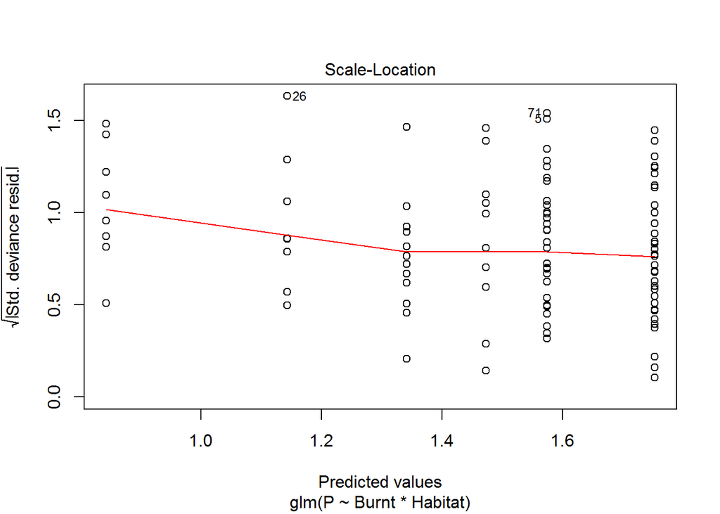

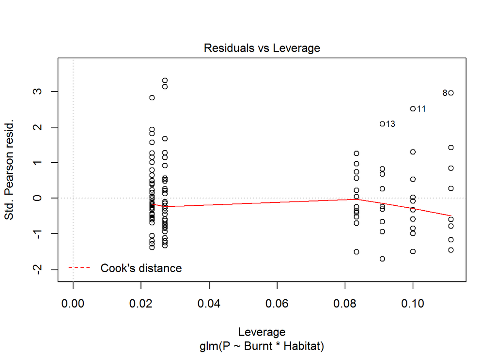

```r
##### Try a gamma distribution with a log link

mod_gamma <- glm(P~Burnt*Habitat, data = chem, family = "Gamma"(link = "log"))
plot(mod_gamma)
```

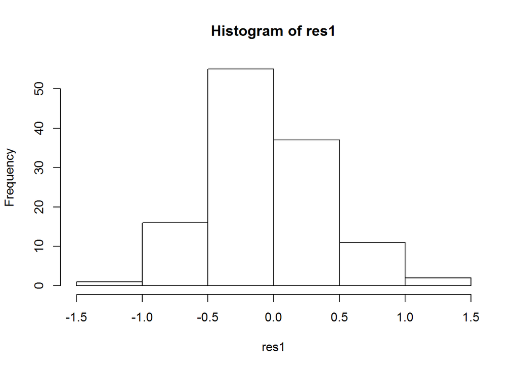

```r
res1 <- residuals(mod_gamma, type = "deviance")

hist(res1)
```

```r
shapiro.test(res1)
```

```
##
##  Shapiro-Wilk normality test
##
## data:  res1
## W = 0.98604, p-value = 0.244
```

```r
#####

summary(mod_gamma)
```

```
##
## Call:
## glm(formula = P ~ Burnt * Habitat, family = Gamma(link = "log"),
##     data = chem)
##
## Deviance Residuals:
##     Min       1Q   Median       3Q      Max
## -1.2024  -0.3232  -0.1129   0.2132   1.1078
##
## Coefficients:
##                  Estimate Std. Error t value Pr(>|t|)
## (Intercept)       1.57367    0.07794  20.192  < 2e-16 ***
## BurntY            0.17896    0.10631   1.683    0.095 .
## HabitatDH        -0.10120    0.16896  -0.599    0.550
## HabitatWH        -0.73115    0.17620  -4.150 6.38e-05 ***
## BurntY:HabitatDH -0.30987    0.22914  -1.352    0.179
## BurntY:HabitatWH  0.12158    0.23813   0.511    0.611
## ---
## Signif. codes:  0 '***' 0.001 '**' 0.01 '*' 0.05 '.' 0.1 ' ' 1
##
## (Dispersion parameter for Gamma family taken to be 0.2247458)
##
##     Null deviance: 32.860  on 121  degrees of freedom
## Residual deviance: 25.202  on 116  degrees of freedom
## AIC: 515.95
##
## Number of Fisher Scoring iterations: 5
```

```r
### N.B. this doesn't do an Anova test, it just produces an Anova table based on the model you have already created.  The 'type =  III' part is important here, as it means that the the order in which terms are listed in the model does not effect the calculated significance (each term is treated as though it were added last).

Anova(mod_gamma, type = "III")
```

```
## Analysis of Deviance Table (Type III tests)
##
## Response: P
##               LR Chisq Df Pr(>Chisq)
## Burnt           2.8177  1   0.093231 .
## Habitat        14.7588  2   0.000624 ***
## Burnt:Habitat   2.4879  2   0.288242
## ---
## Signif. codes:  0 '***' 0.001 '**' 0.01 '*' 0.05 '.' 0.1 ' ' 1
```

```r
##########
```

## **Generalised** linear **Mixed** models

### The key difference between *Generalised* Linear Models and Generalised Linear **Mixed** Models, is that mixed models include ‘Random’ effects.

A Random term in a ‘mixed’ model is used to account for non-independence or pseudoreplication in study design or data.

Common examples include:

- Repeated measures from the same individual over time
- Spatial correlation - Measures taken from same location or group of individuals with a larger study population.
- Temporal correlation – Measures taken on the in the same months or years.
- Nested designs e.g. several quadrats within each site, several chicks within each nest etc.

Mixed models are commonly used for hierarchical study designs and are sometimes also called ‘Hierarchical models’.

#### Deciding whether a variable is ‘random’ or ‘fixed’

This depends on the research question and the hypothesis being tested.

But here are some guiding questions from Thomas et al. “Data analysis with R statistical software”

1. Does the variable represent spatial or temporal autocorrelation, repeated measures or hierarchical structure? - If so, Random
2. Do we want to know how factor levels differ and by how much? i.e. Do we want to estimate the effect size for factor levels? - If so, Fixed
3. Are levels a random sample of a larger “population”? (i.e we haven’t measured all possible categories) - If so, Random

#### Coding mixed models.

There and lots of available packages my favourite is glmmADMB, (but apparantly glmmmTMB is the new fancy option). Here, I use lme4, it’s one of the most commonly used and easily available from Cran.

Model coding formulas follow this format:

i.e. glmer(dependent variable~Explanatory variable + (1|Random factor), family = distribution(link = “”), data = dataset)

#### coding nested random effects

Random effects are specified as e|g, where e is an effect and g is a grouping factor (which must be a factor variable, or a nesting of/interaction among factor variables). For example, the formula would be 1|block for a random-intercept model, with data grouped into blocks. A model of nested random effects (block within site) would be 1|site/block; a model of crossed random effects (block and year) would be (1|block)+(1|year).

*Note: There are more sophiscated methods of dealing with spatial and temporal correlation, when these vary along continous gradients. Random effects are for when time/space are grouped into factorial variables (correlation structures in “?gls”)*

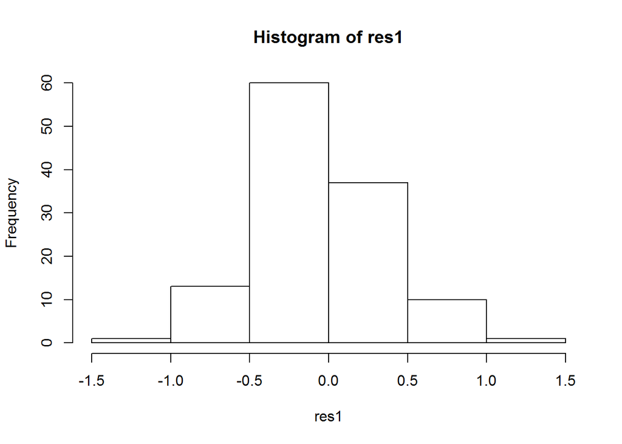

```r
### Using the same dataset as the previous example, but this time using Site as a grouping factor to account for pseudoreplication/correlation of measures within locations


mod_gamma_mixed <- glmer(P~Burnt*Habitat + (1|Site), data = chem, family = "Gamma"(link = "log"))

res1 <- residuals(mod_gamma_mixed, type = "deviance")

hist(res1)
```

```r
shapiro.test(res1)
```

```
##
##  Shapiro-Wilk normality test
##
## data:  res1
## W = 0.99204, p-value = 0.7145
```

```r
####

summary(mod_gamma_mixed)
```

```
## Generalized linear mixed model fit by maximum likelihood (Laplace
##   Approximation) [glmerMod]
##  Family: Gamma  ( log )
## Formula: P ~ Burnt * Habitat + (1 | Site)
##    Data: chem
##
##      AIC      BIC   logLik deviance df.resid
##    504.4    526.8   -244.2    488.4      114
##
## Scaled residuals:
##     Min      1Q  Median      3Q     Max
## -1.8240 -0.6537 -0.1168  0.4640  3.6389
##
## Random effects:
##  Groups   Name        Variance Std.Dev.
##  Site     (Intercept) 0.02504  0.1583
##  Residual             0.17696  0.4207
## Number of obs: 122, groups:  Site, 6
##
## Fixed effects:
##                  Estimate Std. Error t value Pr(>|z|)
## (Intercept)       1.45380    0.13318  10.916   <2e-16 ***
## BurntY            0.21919    0.09335   2.348   0.0189 *
## HabitatDH         0.18920    0.18683   1.013   0.3112
## HabitatWH        -0.34717    0.20417  -1.700   0.0891 .
## BurntY:HabitatDH -0.28725    0.19781  -1.452   0.1465
## BurntY:HabitatWH  0.09654    0.20425   0.473   0.6365
## ---
## Signif. codes:  0 '***' 0.001 '**' 0.01 '*' 0.05 '.' 0.1 ' ' 1
##
## Correlation of Fixed Effects:
##             (Intr) BurntY HbttDH HbttWH BY:HDH
## BurntY      -0.379
## HabitatDH   -0.299  0.221
## HabitatWH   -0.293  0.204  0.542
## BrntY:HbtDH  0.165 -0.470 -0.509 -0.050
## BrntY:HbtWH  0.170 -0.446 -0.113 -0.543  0.210
```

```r
###  Out of curiousity let's compare this output with that of the previous GLM without accounting for correlation within sites.

Anova(mod_gamma_mixed, type = "III")
```

```
## Analysis of Deviance Table (Type III Wald chisquare tests)
##
## Response: P
##                  Chisq Df Pr(>Chisq)
## (Intercept)   119.1523  1    < 2e-16 ***
## Burnt           5.5136  1    0.01887 *
## Habitat         8.1838  2    0.01671 *
## Burnt:Habitat   2.7410  2    0.25398
## ---
## Signif. codes:  0 '***' 0.001 '**' 0.01 '*' 0.05 '.' 0.1 ' ' 1
```

```r
Anova(mod_gamma, type = "III")
```

```
## Analysis of Deviance Table (Type III tests)
##
## Response: P
##               LR Chisq Df Pr(>Chisq)
## Burnt           2.8177  1   0.093231 .
## Habitat        14.7588  2   0.000624 ***
## Burnt:Habitat   2.4879  2   0.288242
## ---
## Signif. codes:  0 '***' 0.001 '**' 0.01 '*' 0.05 '.' 0.1 ' ' 1
```

```r
### Here we can see that the effect of burning on soil phosphorous only becomes obvious after accounting from the effect of differences between sites.
```

## Recommended resources

http://glmm.wikidot.com/

https://github.com/Ruth-R-Kelly/TCD-R-users-group-resources - (see Andrew Jacksons intro to glmms and Kevin Healy’s MCMCglmm)

Articles Bolker, et al. 2009. Generalized linear mixed models: a practical guide for ecology and evolution. Trends in Ecology & Evolution 24: 127-135.

```
Zuur AF, Ieno EN, Elphick CS.. A protocol for data exploration to avoid common statistical problems. Methods Ecol Evol 1: 3-14
```

Books

Everything you ever needed to know : Zuur et al. 2009 Mixed Effects Models and Extensions in Ecology with R

A practical how to guide : Thomas et al. Data Analysis with R statistical Software: A Guidebook for Scientists